# bis620

## team

Laura Sun (ls3474)

Yutong Ge (yg393)

Yongzhuo Chen(yc896)

Ruiqiu Zhang(rz345)

## description of the data

We will be using the panitumumab clinical trial data. We will be studying whether age, sex, race, geographic region, KRAS status, Eastern Coorperative Oncology Group Performance Status affect death outcome. Knowing this would help with predicting death.

## motivation

According to the Precision Medicine Initiative, precision medicine is “an emerging approach for disease treatment and prevention that takes into account individual variability in genes, environment, and lifestyle for each person.” This approach will allow doctors and researchers to predict more accurately which treatment and prevention strategies for a particular disease will work in which groups of people. The dataset in this project comes from the result of Panitumumab Randomized Trial in combination with Chemotherapy for Metastatic Colorectal Cancer. The analysis of the data could help determine in which group of people the treatment protocol has a specific effect. Therefore, the purpose of this study is to determine whether the Baseline Characteristics will influence the treatment effect of panitumumab in combination with FOLFOX compared to FOLFOX alone as first line therapy for metastatic colorectal cancer, providing many cancer patients with targeted drugs and helping them receive the matched treatment they each need for their type of genes or baseline characteristics. This reduces the use of treatments which might be less effective and their potential side effects.

## Scientific research question

Are the patients’ Baseline Characteristics, including age, sex, race, geographic region, KRAS Status, Eastern Cooperative Oncology Group Performance Status and primary tumor type will influence the treatment effect of panitumumab in combination with FOLFOX compared to FOLFOX alone as first line therapy for metastatic colorectal cancer?

## 4. Analysis

### Descriptive Statistics

#### Basic information of variables

This function provide the basic information about baseline characteristics of participants in different groups, including the average and standard deviation of age(unit: years), sex(including female and male, measure type: count of participants, unit: participants), race/ethnicity(including White or Caucasian, Black or African American, Hispanic or Latino, Asian and Other, measure type: number, unit: participants). This function is used to present quantitative descriptions in a manageable form, helping us to simplify large amounts of data in a sensible way.

```r
devtools::load_all()
```

```
#> ℹ Loading bis620.2022
```

```r
data("ukb_accel")
library(bis620.2022)
summary_baseline(ukb_accel)
```

```
#>                 FOLFOX alone Panitumumab + FOLFOX
#> male                  281.00               298.00
#> female                186.00               170.00
#> mean_age               60.48                61.48
#> std_age                11.12                10.02
#> mean_weight            72.31                72.95
#> std_weight             16.00                15.42
#> mean_height           167.35               167.48
#> std_height              9.28                 9.35
#> Asian                   4.00                 7.00
#> Black_African           7.00                 5.00
#> Hispanic_Latino        19.00                29.00
#> Other                   4.00                 4.00
#> White_Caucasian       433.00               423.00
```

#### Sex

This is a visualization function which provides the plot of number of total male and female counts conditioned on different types of intervention/treatment, presenting a quantitative description in a sensible way.

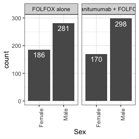

```r
summary_sex(ukb_accel)
```

#### response

This is a visualization function which provides the plot of number of each type of best response, faceted by arm. In a phase 2 trial, a positive endpoint considered when a patients see partial or complete response and is measured per patient in the overall response variable. Responses are recorded multiple times. It is supposed that the best response is the most favorable over the course of treatment and can be “Complete Response”, “Partial Response”, “Stable Disease”, and “Progressive Disease, with”Complete Response” being the best and “Progressive Disease” being the worst. This visualization highlights the potential relationship between the intervention/treatment and the response.

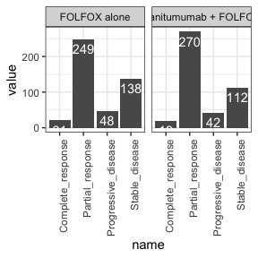

```r
summary_response(ukb_accel)
```

#### KRAS

This is a visualization function which provides the plot of number of total mutant, wild-type, and unknown KRAS counts conditioned on different types of intervention/treatment, presenting a quantitative description in a sensible way. It is supposed that a patient will be considered “Mutant” if there is at least one “Mutant” biomarker in KRAS exons 3, 4, or 5. Patients will be considered “Wild-type” if they are not “Mutant” and they have more “Wild-type” markers than “Unknown” or “Failure”.

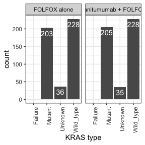

```r
summary_kras(ukb_accel)
```

### Linear Regression

This is a function that establishes main linear models in this eassy. Firstly, the main dataset is the join of adsl,adae and biomark using the primary key “SUBJID”. For the some catagorical variables, the factor( ) and as.numeric ( ) function is used to transform “SEX”,“RACE”,“ATRT”, “BMMTR1” into numeric variables. “DTH” is uesd as the Y in the linear models. The seven variables are x1_sex, x2_race, x3_atrt, x4_biomark, x5_age, x6_weight, x7_height.

```r
linear_regression(ukb_accel)
```

```
#> Linear mixed-effects model fit by REML
#>   Data: unique(dataset)
#>        AIC      BIC    logLik
#>   1163.568 1207.055 -572.7838
#>
#> Random effects:
#>  Formula: ~1 | x4_biomark
#>         (Intercept)  Residual
#> StdDev:  0.09070558 0.4339712
#>
#> Fixed effects:  y ~ x1_sex + x2_race + x3_atrt + x5_age + x6_weight + x7_height
#>                   Value Std.Error  DF    t-value p-value
#> (Intercept) -0.14334857 0.4272887 924 -0.3354841  0.7373
#> x1_sex       0.04646089 0.0396244 924  1.1725323  0.2413
#> x2_race      0.01848913 0.0252543 924  0.7321171  0.4643
#> x3_atrt     -0.02278780 0.0284832 924 -0.8000441  0.4239
#> x5_age       0.00276734 0.0013978 924  1.9797510  0.0480
#> x6_weight   -0.00159206 0.0011129 924 -1.4305361  0.1529
#> x7_height    0.00491840 0.0022723 924  2.1644949  0.0307
#>  Correlation:
#>           (Intr) x1_sex x2_rac x3_trt x5_age x6_wgh
#> x1_sex    -0.700
#> x2_race   -0.201  0.055
#> x3_atrt   -0.105  0.029 -0.023
#> x5_age    -0.397  0.236  0.099 -0.040
#> x6_weight  0.196  0.061  0.067 -0.015 -0.087
#> x7_height -0.931  0.567  0.106  0.015  0.203 -0.427
#>
#> Standardized Within-Group Residuals:
#>        Min         Q1        Med         Q3        Max
#> -2.0637428 -1.4198519  0.4669353  0.6902746  0.9945908
#>
#> Number of Observations: 934
#> Number of Groups: 4
#>
#> Call:
#> lm(formula = y ~ x1_sex + x2_race + x3_atrt + x4_biomark + x5_age +
#>     x6_weight + x7_height, data = unique(dataset))
#>
#> Residuals:
#>     Min      1Q  Median      3Q     Max
#> -0.9414 -0.6162  0.2084  0.2985  0.4281
#>
#> Coefficients:
#>              Estimate Std. Error t value Pr(>|t|)
#> (Intercept)  0.015548   0.427552   0.036   0.9710
#> x1_sex       0.045808   0.039700   1.154   0.2489
#> x2_race      0.019020   0.025296   0.752   0.4523
#> x3_atrt     -0.020460   0.028522  -0.717   0.4733
#> x4_biomark  -0.060285   0.013160  -4.581 5.26e-06 ***
#> x5_age       0.002844   0.001400   2.032   0.0425 *
#> x6_weight   -0.001631   0.001114  -1.465   0.1434
#> x7_height    0.004758   0.002276   2.091   0.0368 *
#> ---
#> Signif. codes:  0 '***' 0.001 '**' 0.01 '*' 0.05 '.' 0.1 ' ' 1
#>
#> Residual standard error: 0.4348 on 926 degrees of freedom
#> Multiple R-squared:  0.03135,    Adjusted R-squared:  0.02402
#> F-statistic: 4.281 on 7 and 926 DF,  p-value: 0.0001138
```

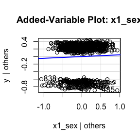

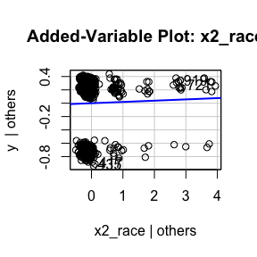

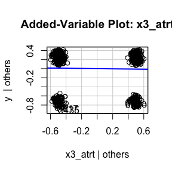

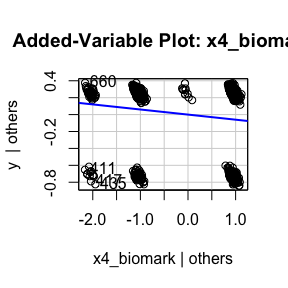

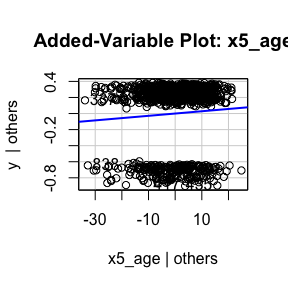

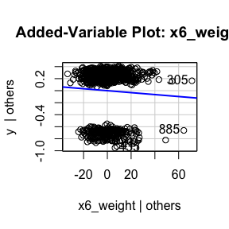

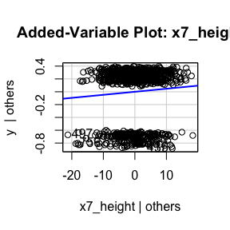